# Short Lab: PCA

## Part 1. Pairwise Plot

We will start by plotting the data using a pairwise plot for exploratory data analysis. You will need the `GGally` package to run the code below. First install the package if you haven’t already.

```r
# install.packages("GGally")
library(palmerpenguins)
library(tidyverse)
library(GGally)
data(penguins)
```

Note the plotting code below comes from the excellent Allison Horst, [available here](https://allisonhorst.github.io/palmerpenguins/articles/articles/pca.html).

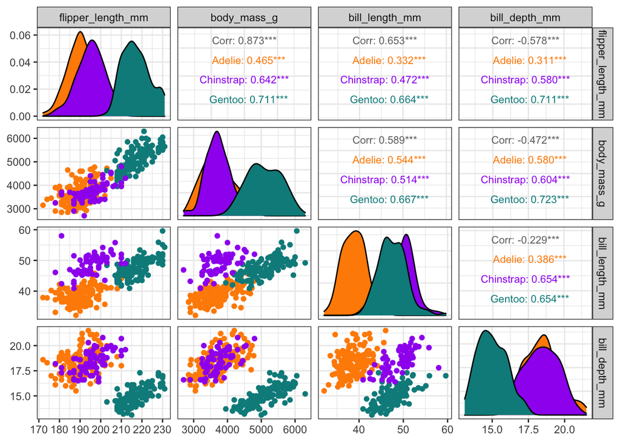

```r
penguins <- penguins %>% drop_na()
penguins %>%
  select(species, where(is.numeric)) %>%
  GGally::ggpairs(aes(color = species),
          columns = c("flipper_length_mm", "body_mass_g",
                      "bill_length_mm", "bill_depth_mm"),
          upper = list(continuous = wrap("cor", size = 3))) +
  scale_colour_manual(values = c("darkorange","purple","cyan4")) +
  scale_fill_manual(values = c("darkorange","purple","cyan4")) +
  theme_bw()
```

**1.** Comment on what you see in the plot above. Use several sentences, as later in this short lab you will be comparing your conclusions here to those from PCA. Focus on the associations between species and the various quantitative variables, and how those associations differ across species.